# Exploratory Report

Patrick Cheng, Erica Gordy, William Siauw, Joel Yang

2021-03-12

## Problem Domain – Incarceration Rate in the US

[output not shown]

## Data Description

The datasets detail raw statistics such as income in cities and counties across the United States, crime statistics in Washington, and incarcerated populations by state.

Most of these datasets come from [Kaggle](https://www.kaggle.com/), an online data science environment where numerous data sets are published for free use. The exception is our “Criminal Justice Data Book” set, which comes from [Data.gov](https://www.data.gov/), a government hosted website.

The crime dataset looks something like this:

```
##      county POP_F_TOTAL POP_M_TOTAL POP_TOTAL JDP_TOTALADP PDP_TOTAL ARN_TOTAL
## 1     state     3599991     3583709   7183700      -99.000      8408    145253
## 2      king     1053585     1051515   2105100     2023.388      1519     35570
## 3    pierce      427452      417038    844490     1171.000      1096     19137
## 4 snohomish      385237      387623    772860      901.000       630     16041
## 5   spokane      248085      244445    492530      942.000       715      2902
##   JRN_TOTAL total_arrest
## 1     12148       157401
## 2      2207        37777
## 3      1536        20673
## 4      1404        17445
## 5       305         3207
```

The income dataset looks something like this:

```
## # A tibble: 6 x 5
##   County     Mean Median `Standard Deviation` sum_w
##   <chr>     <dbl>  <dbl>                <dbl> <dbl>
## 1 adams    75980. 61815.               51178. 476.
## 2 clallam  32393  25578                25813  377.
## 3 douglas  42039  36927                29171  530.
## 4 ferry    50538  20511                28798.  51.0
## 5 franklin 56676  48756                43462  675.
## 6 grant    46120  29646                49765  311.
```

Our modified income dataframe is relatively straightforward, giving secondary statistics such as the mean, median and standard deviation of each respective county in Washington. sum_w refers to the number of houses sampled per county.

Our crime in 2016 dataframe is a bit more confusing, but it becomes more readable once the abbreviations are understood. - PDP refers to prison admits, - JDP refers to jail admits, - and POP refers to total population (including the incarcerated).

## Summary Analysis

For the crime data frame, we took the mean values for each age group. Then we went county by county gathering mean, median, min, and max for both Male and Female. For this we used the POP_F_TOTAL and POP_M_TOTAL column data.

For the income data frame, we began by looking at national data. We also added a column so that we could see the county and state names together. We looked at mean, median, min, and max data nationally and then focused on WA state, repeating the same stats for WA counties.

Below are some of the most relevant statistics from the data sets. Crime Data in WA state:

```
## [1] 78617.61
```

```
## [1] 77991.09
```

County with the Most Female Incarcerated

```
## [1] "KING"
```

County with the Most Male Incarcerated

```
## [1] "KING"
```

County with the Least Female Incarcerated

```
## [1] "GARFIELD"
```

County with the Least Male Incarcerated

```
## [1] "GARFIELD" "GARFIELD"
```

Income Data: Mean National Income:

```
## [1] 66703.99
```

Washington State Statistics:

```
##       Mean Median
## 1 74067.36  63196
```

Washington State Statistics By County:

[output not shown]

## Summary Plots

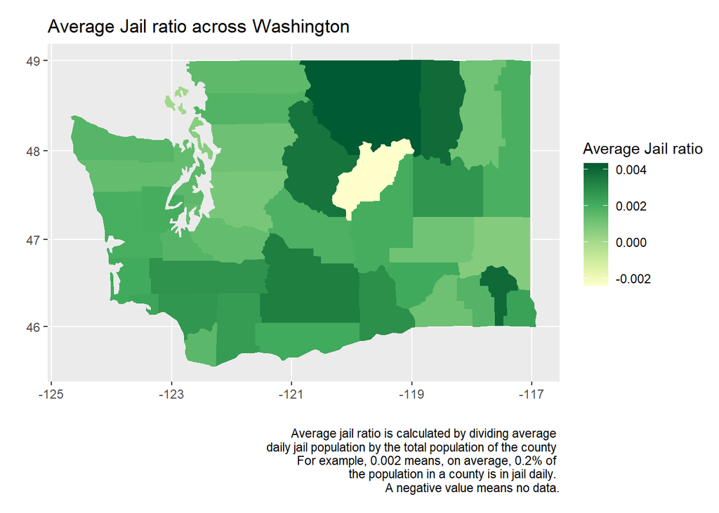

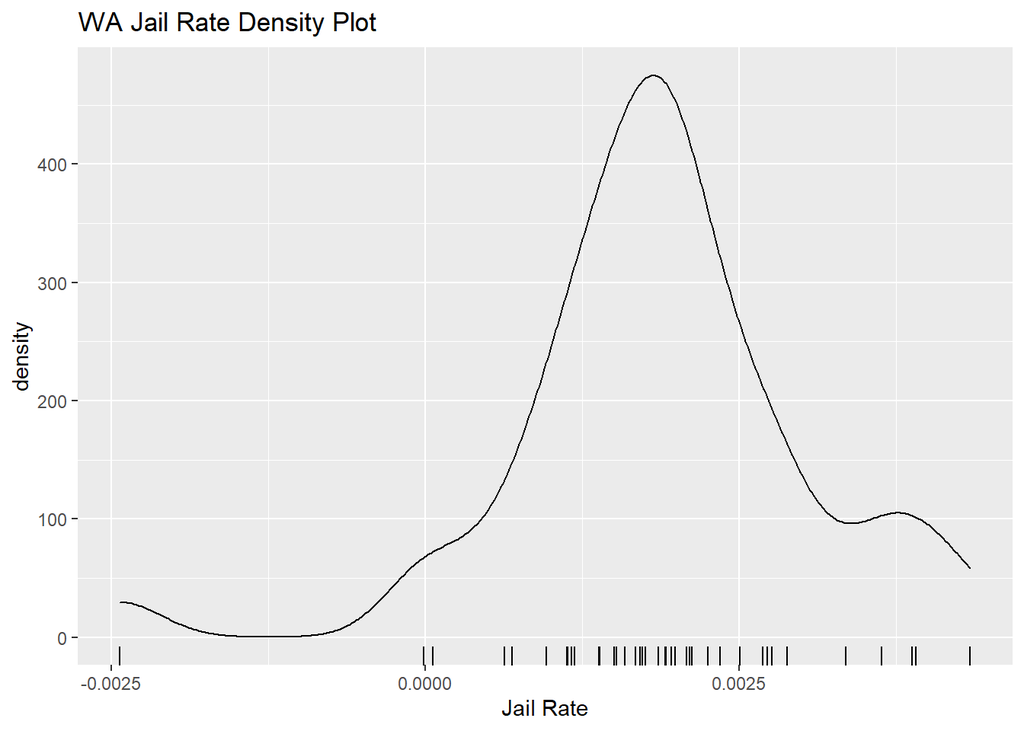

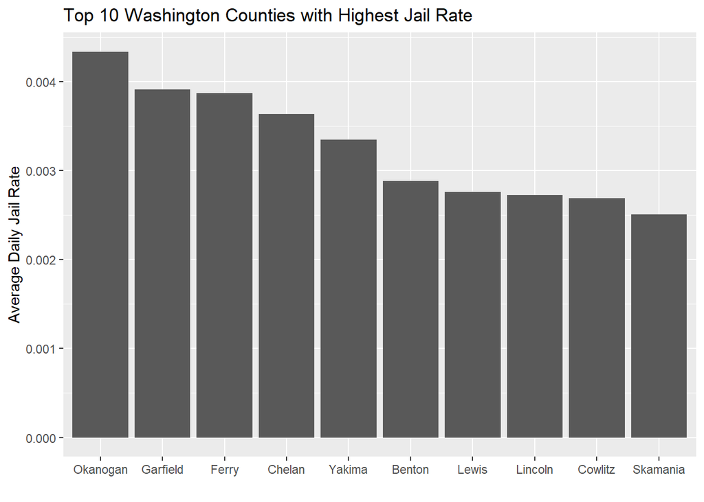

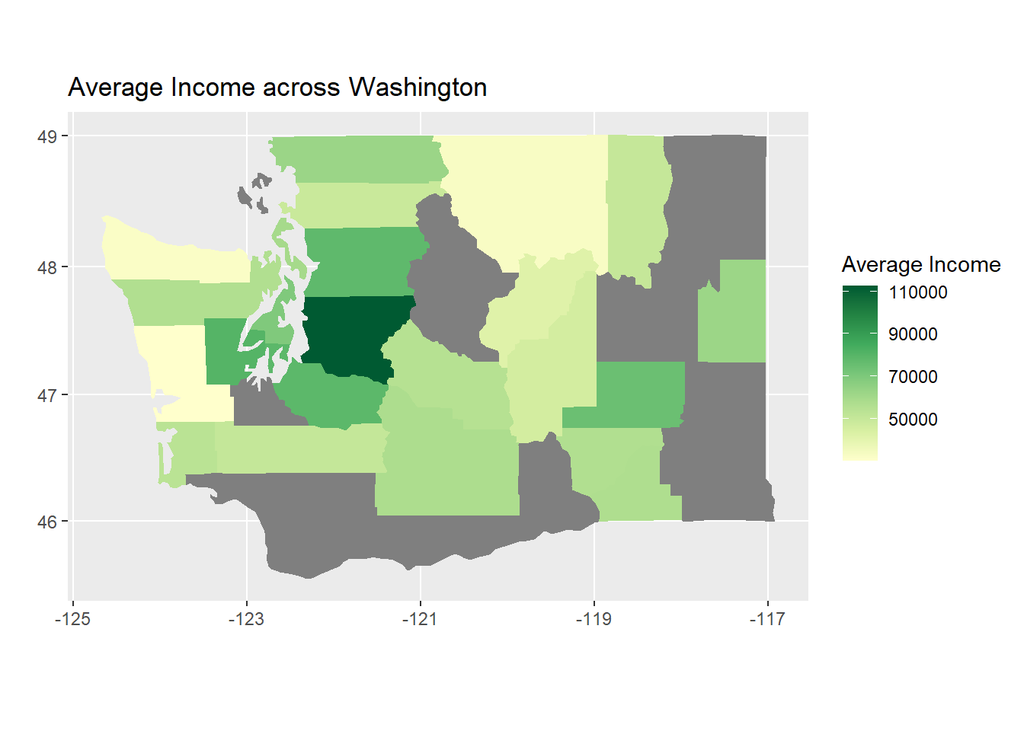

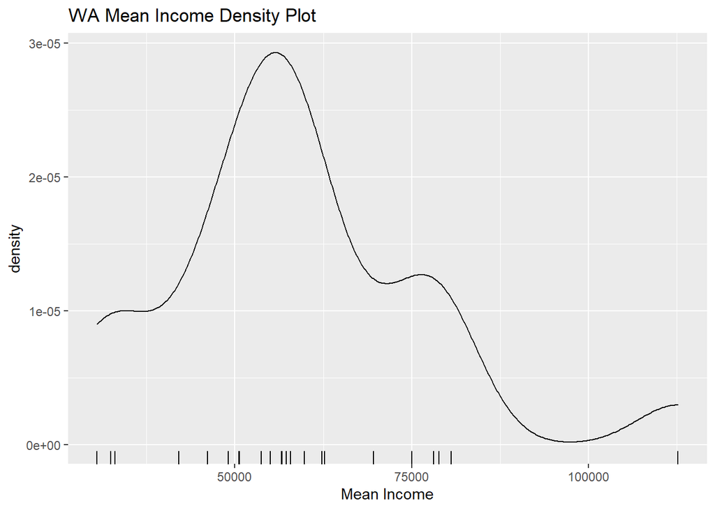

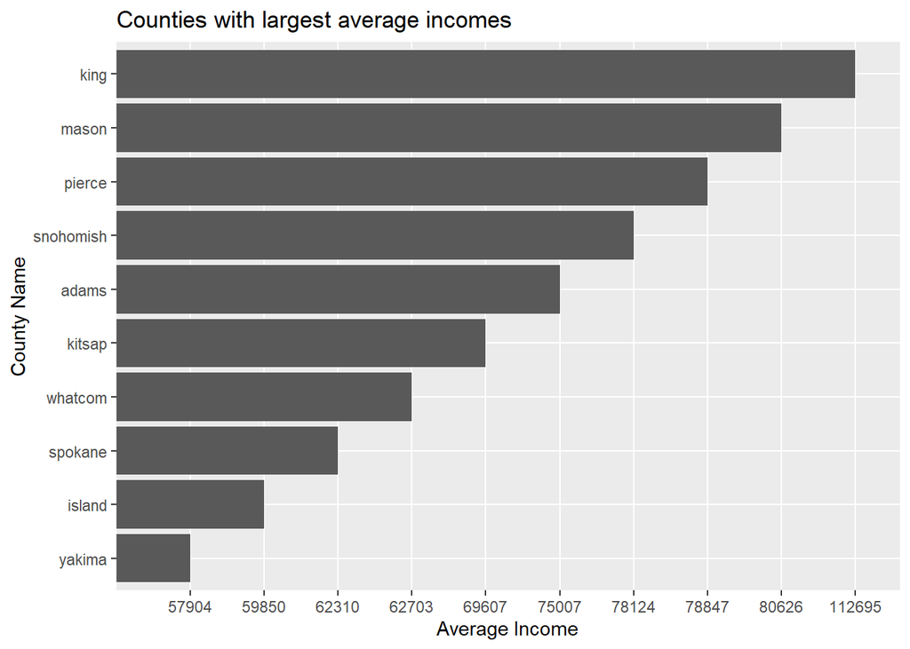

### Outliers

In this income graph, there are a few counties with no data. This missing data could be due to a plethora of reasons, such as maybe a low population in said county, or simply not enough information. Additionally, Douglas county is missing daily average jail population data. We aren’t too sure what might result in this, but possibly poor reporting or large swathes of missing information.

## Question Analyses

### Are people of different economic status punished by law differently in the state of Washingtion?

For this questions we are going to be looking at how average sentence time compares to the median incomes in that same county. We chose to use median incomes to avoid outliers messing with the calculations.

Here is some info about the county with the highest income.

```
##   county APS_AVG_SENT
## 1   king         49.1
```

Here is some info about the county with the lowest income.

```
##   county APS_AVG_SENT
## 1  ferry         27.6
```

Here is some info about the county with the highest sentence time.

```
##   county  Median
## 1 island 44366.5
```

Here is some info about the county with the lowest sentence time.

```
##   county Median
## 1  ferry  20511
```

We want to see if higher income counties have low sentence times and vice versa about low income counties. In order to do this we put the data we needed into a dataframe and produced some charts to help visualize the data.

```
##      county APS_AVG_SENT   Median
## 1     adams         31.4 61814.61
## 5   clallam         30.3 25578.00
## 9   douglas         30.0 36927.00
## 10    ferry         27.6 20511.00
## 11 franklin         28.2 48756.00
## 13    grant         34.0 29646.00
```

Below is a scatter plot showing the average sentence time and median income plotted together.

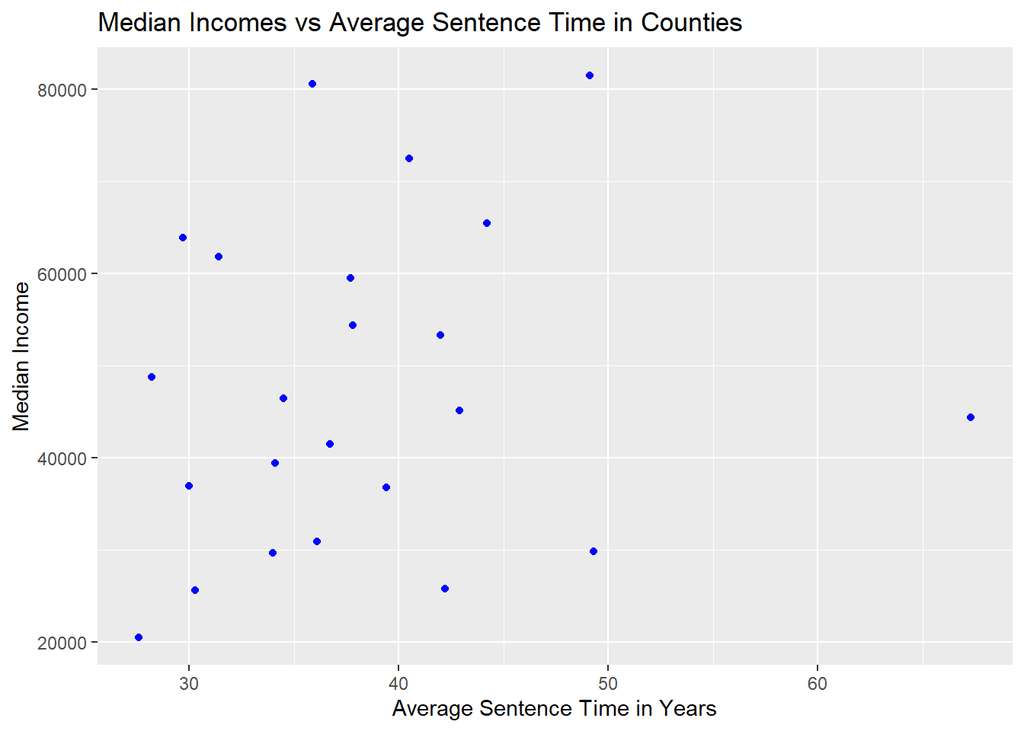

### How is the relationship between the rate of people getting arrested and the rate of people being sentenced to prison affected by economic status in the state of Washington?

When an individual is arrested, it doesn’t always mean he or she is going to jail or prison because it depends on the crime committed, and if the individual has the financial ability to pay the fine or bail. In this case, we expect counties with better economic status (estimated by income median) to have a smaller prison-arrest ratio – the number of prison admissions compared to number of arrests – because people in richer counties are more likely to have the ability to pay the fine or bail instead of serving their sentence time in prison.

The rate of people getting arrested is the number of total people arrested in a year divided by total population of the county. The rate of prison sentence is the number of total prison admission in a year divided by total population of the county.

The relationship between the arrest rate and prison sentence rate in a certain county is calculated by dividing the total number of prison admission in a year by total number of people arrested in that year. Then I compare the result to the median income of the county.

```
##          county prison_to_arrest_rate income_median
## 1         ferry            0.57142857      20511.00
## 2       spokane            0.22294980      54392.33
## 3       pacific            0.16708229      30912.00
## 4      okanogan            0.08263773      25738.33
## 5        kitsap            0.07886754      59525.33
## 6         lewis            0.07138158      45146.50
## 7      kittitas            0.06558704      29794.00
## 8   walla walla            0.06068376      46473.00
## 9       whatcom            0.05564716      63865.00
## 10        grant            0.05411103      29646.00
## 11 grays harbor            0.05376724      36788.00
## 12       pierce            0.05301601      65475.60
## 13       island            0.05257937      44366.50
## 14       yakima            0.05096701      53290.00
## 15       skagit            0.04460606      39390.00
## 16     franklin            0.04152128      48756.00
## 17         king            0.04020965      81556.20
## 18      clallam            0.03907075      25578.00
## 19        mason            0.03615960      80626.00
## 20    snohomish            0.03611350      72509.00
## 21    jefferson            0.03089431      41472.00
## 22      douglas            0.03087649      36927.00
## 23        adams            0.02953586      61814.61
```

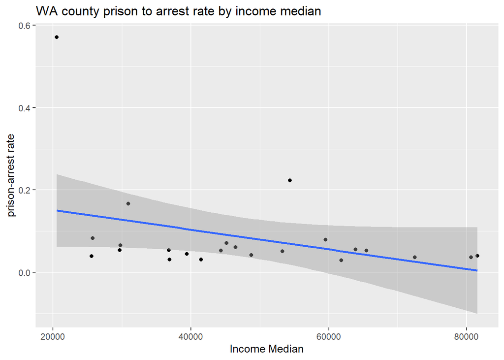

### How does the economic status of residents in a given county correlate with the incarceration rate in the state of Washington?

For this question, we wanted to examine if there were any correlations between a county’s mean income and it’s rate of incarceration.

In order to answer this question, we simply compared the two maps exploring economic status in Washington to the map exploring incarceration across Washington. We also joined the 2 datasets themselves in order to examine if there was indeed a correlation between the two variables.

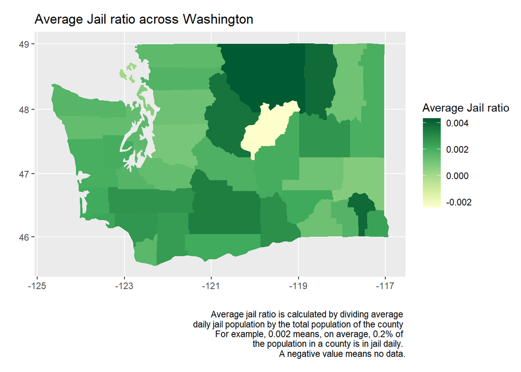

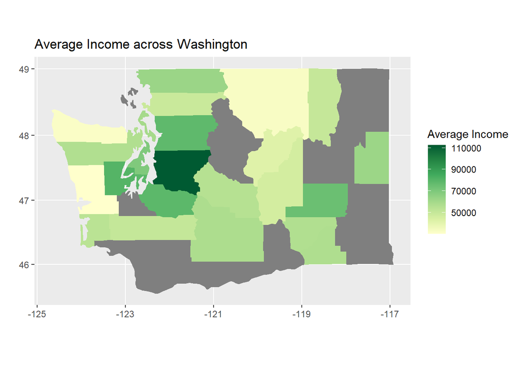

It looks like there is a loose inverse correlation between a county’s average income and it’s incarceration rate. For instance, The correlation coefficient between a county’s average income and its incarceration rate is -0.2028428. As the correlation coefficient shows, as a county’s average income increases, for the most part its rate of incarceration will decrease, with a strength of roughly 0.2.

With this information, future studies might be conducted regarding this correlation. Why is it that roughly speaking, poorer counties tend to have larger rates of incarceration? Is this out of desperation, lack of opportunity? Is this a cultural aspect? Hopefully more light can be shed in the future regarding this connection.

Admittedly, there are some shortcomings with this specific analysis. For one, we only compared counties in Washington state, this correlation might not hold true in other parts of the country, or even the rest of the world. Furthermore, our dataset regarding income had many missing data points for some counties, as a result, there are some patches in our graphs, which might be misrepresentative. Furthermore, we decided to focus on average income in this analysis. Averages are much more susceptible to outliers, such as incredibly rich or poor people in this case. As a result, such people could have skewed our data and findings. We decided to focus on averages as they are much easier to compute, when given an existing average. While analyzing county medians might be more representative, I feel like taking the average of medians might not be as informative or even concrete.

### How does the type of crime committed relate to the geographic location of the crime and the economic status of the area in the state of Washington?

Not only did we want to focus on incarcerated populations, we wanted to see what factors led to them. Overpolicing and arrests in different classes of counties appeared to be a good lead. By “economic status of the area”, we referred to the mean income of each county, which, in hindsight, may have inflated the incomes of richer counties. For the “type of crime”, we used the crimes listed in the codebook, filtering out crimes that had a negligibly low proportion in comparison to other crimes (e.g. arson).

To answer this, we created two plots. In order to compare areas of higher income with areas of lower income, one plot listed counties with more than $75,000/year mean income, and the other listed counties with less than $50,000/year. We first joined the Washington county income dataset with the Washington crime dataset, getting the crime proportions by dividing the amount of each crime committed by the total amount of crimes committed. We then filtered out crimes with occurrences of less than 2%, which also assured we got the same types of crimes for both plots.

Below are the data frames that depict the most and least affluent counties by crime proportions, respectively:

```
## # A tibble: 5 x 8
##   County assault_proport~ burglary_propor~ destruction_pro~ drug_violation_~
##   <chr>             <dbl>            <dbl>            <dbl>            <dbl>
## 1 adams            0.25             0.0171          0.0394            0.123
## 2 king             0.175            0.0254          0.0260            0.0564
## 3 mason            0.0666           0.0216          0.00721           0.0589
## 4 pierce           0.195            0.0395          0.0259            0.0756
## 5 snoho~           0.211            0.0294          0.0236            0.154
## # ... with 3 more variables: group_b_proportion <dbl>, theft_proportion <dbl>,
## #   violation_no_contact_proportion <dbl>
```

```
## # A tibble: 6 x 8
##   County assault_proport~ burglary_propor~ destruction_pro~ drug_violation_~
##   <chr>             <dbl>            <dbl>            <dbl>            <dbl>
## 1 clall~           0.252            0.0295           0.0509           0.0972
## 2 dougl~           0.134            0.0258           0.0224           0.0943
## 3 grant            0.218            0.0621           0.0346           0.0821
## 4 grays~           0.151            0.0279           0.0346           0.0919
## 5 okano~           0.0880           0.0335           0.0141           0.0379
## 6 skagit           0.180            0.0399           0.0243           0.103
## # ... with 3 more variables: group_b_proportion <dbl>, theft_proportion <dbl>,
## #   violation_no_contact_proportion <dbl>
```

Below are the plots for these data frames:

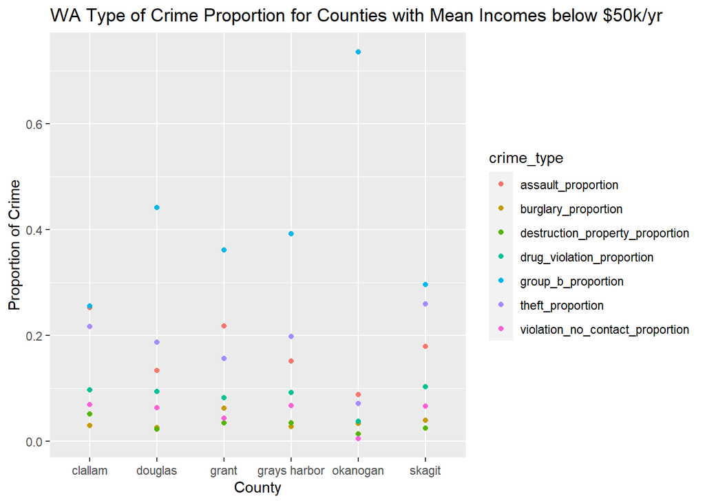

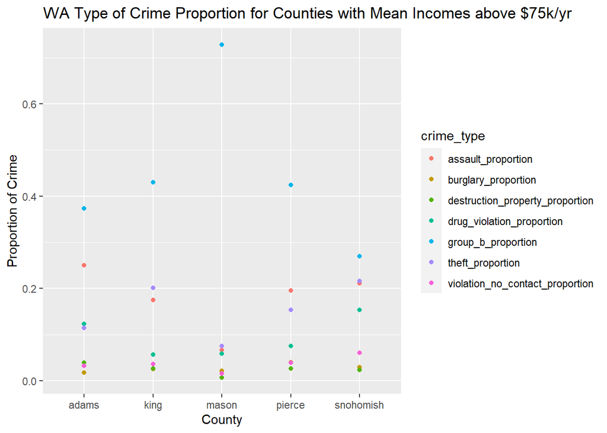